# Dungeness River Winter Steelhead SONAR-based Escapement Estimates

2019 - 2024

Bethany Craig<sup>1,✉</sup>, Kevin See<sup>1</sup>, and Joseph Anderson<sup>1</sup>

May 16, 2025

<sup>1</sup> Washington Department of Fish & Wildlife

<sup>✉</sup> Correspondence: Bethany Craig <Bethany.Craig@dfw.wa.gov>

# 1 Executive Summary

This report contains methods and results of SONAR-based escapement estimates for naturally spawning winter steelhead on the Dungeness River from 2019-2024. The Washington Department of Fish and Wildlife (WDFW) deployed a multibeam SONAR unit in the lower Dungeness River during the majority of the steelhead return from either early February or early March through the end of June or July, 2018-2024. Although the SONAR was operated in 2018, we were not able to produce a SONAR-based escapement estimate for 2018 due to frequent milling behavior at the site, and limited data review. We initiated a sub-sampling protocol in 2019 to enable us to review the entire season of imagery, and this was continued in subsequent years.

To exclude similarly sized fish that were not steelhead from our SONAR counts, WDFW conducted weekly species composition sampling in 2021-2024 throughout the periods of SONAR operation. The majority of fish encountered were steelhead and bull trout and these species overlapped in length. To exclude potential bull trout from the SONAR fish counts we fit a binomial generalized additive model (GAM) with a logit link, using splines of fork length and Julian day to predict the probability of a fish being a steelhead. The probability of being a steelhead was greatest during March and April, and least in February and June when fewer steelhead were present.

We learned some important lessons over the first 7 years of SONAR operation on the Dungeness River. Site selection is important and may need to change if fish aren’t actively migrating past the site. For future seasons we recommend deploying the SONAR in January, to capture the start of the steelhead return. We also recommend considering re-designing the species composition sampling to attempt to exclude holding fish, and to investigate how species composition changes with hour of day, since returning steelhead appear to move primarily in the late evening. Finally, we recommend investigating methods to account for kelts that are less simplistic than the methods we used here, and investigating methods for estimating pHOS.

# 2 Introduction

Dungeness River steelhead (*Oncorhynchus mykiss*) are part of the Puget Sound Steelhead Distinct Population Segment (DPS), which includes all naturally spawned steelhead below migration barriers in the rivers flowing into the Strait of Juan de Fuca from the Elwha (inclusive) eastward, Hood Canal, and Puget Sound (Myers et al. 2015). The Puget Sound steelhead DPS was listed as threatened under the Endangered Species Act (ESA) in May 2007, and subsequent species status reviews have upheld the threatened listing (Ford et al. 2011; Northwest Fisheries Science Center 2015). The Dungeness steelhead population is considered a mixed winter/summer run population. Historic accounts from the 1940s describe summer-run steelhead in the Dungeness River in July and August, but it is unclear whether a summer-run population still exists alongside or distinct from the winter population (Myers et al. 2015). Steelhead in the Dungeness spawn in the mainstem Dungeness up to a waterfall above Gold Creek (RKM 30), in the Gray Wolf River up to RKM 15.5, and in Canyon Creek up to RKM 2.7; there is also limited spawning in other small tributaries (e.g., Hurd Creek, Hatchery Creek).

In addition to the natural winter steelhead population, the Washington Department of Fish and Wildlife (WDFW) has released hatchery-propagated early winter steelhead (EWS) into the Dungeness River for decades to provide fishing opportunities for sport and tribal anglers. EWS have been selected for early maturation and early return and spawn timing; Dungeness EWS return to the Dungeness Hatchery (RKM 16.9) between late December and the end of January. All eggs are taken by January 31st to maintain temporal separation with the later timed natural winter steelhead population. EWS-directed fisheries occur in some years from the mouth to the Forks of the mainstem Dungeness and the Gray Wolf Rivers at RKM 25.4 between November 30 and January 31.

The Dungeness River is snowmelt dominated and glacially influenced, with headwaters in the Olympic Mountains (Myers et al. 2015). Glacial sediments and springtime snowmelt can lead to high, turbid water and unsafe survey conditions, presenting a challenge to steelhead redds surveys in the basin. In most years it is not possible to survey for steelhead through the entirety of the spawning season, and in some years poor survey conditions prevent an adequate number of surveys from being completed to produce an estimate of escapement based on redd counts. Current methods use a run-timing curve from 2015, a low water year in which redds surveys could be conducted through the entire spawning period, to expand the current year’s redd counts to generate an escapement estimate. However, this method does not account for the annual variation in flows and spawn timing, which limits accuracy of abundance estimates. Accurate estimates of steelhead escapement in the Dungeness are important to monitor the abundance and health of the population, to evaluate progress towards ESA recovery goals, and to manage potential future fisheries.

SONAR may provide an alternative method for steelhead enumeration and run timing in a dynamic, turbid snow-melt system like the Dungeness watershed. SONAR can be operated in a range of flow conditions and is not limited by turbidity. Since 2018 WDFW has operated a stationary multi-beam SONAR unit in the lower Dungeness River to enumerate and gather run-timing information on Dungeness steelhead. This is our annual report on the SONAR project, covering the 2018-2024 seasons.

# 3 Methods

## 3.1 SONAR operation

We deployed the ARIS 1800 Explorer, manufactured by Sound Metrics, of Bellevue, Washington in the lower Dungeness River during the majority of the steelhead run from 2018 through 2024 (Figure 3.1). The ARIS 1800 uses 96 beams at 1.1/1.8 megahertz (Mhz) to project a 28-degree acoustic wedge. The SONAR unit was adjusted to have a pitch of 3.5 degrees to -8 degrees to ensonify the entire water column and channel. The unit was checked daily and adjusted as necessary to maintain full ensonification of the channel. Imagery was continuously recorded 24 hours a day, and saved in 30-minute files, so that 48 individual files were recorded for each full day of operation.

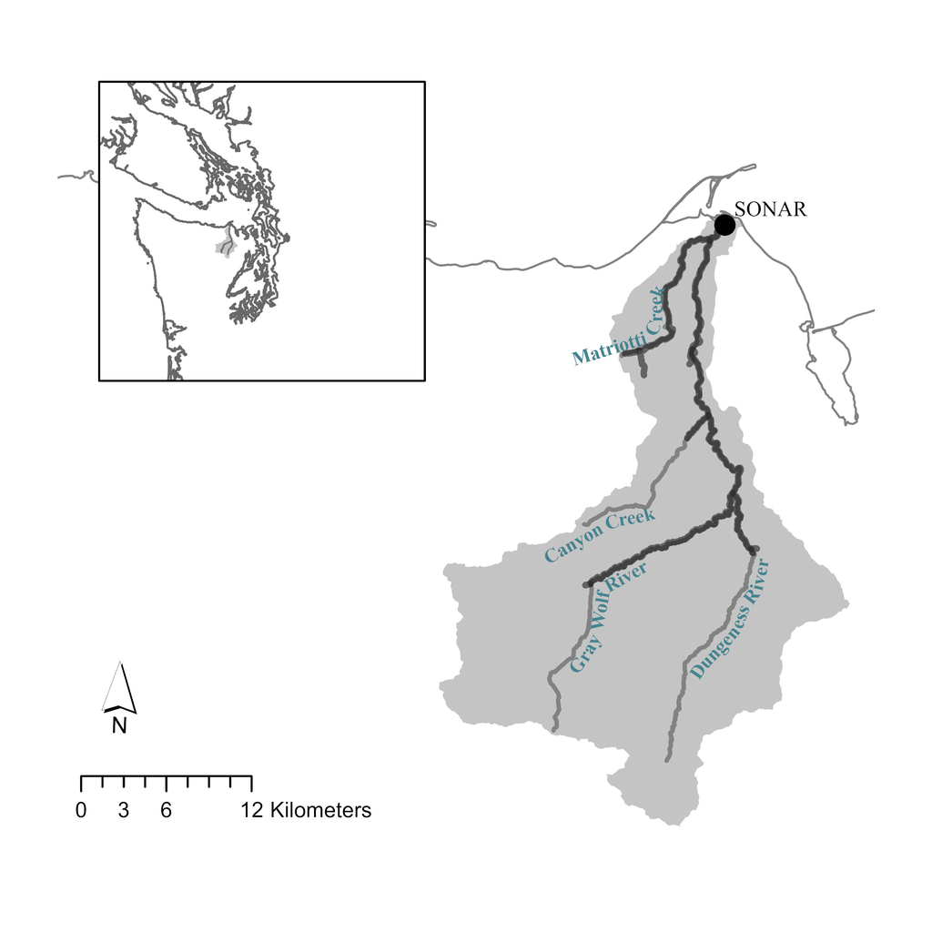

Figure 3.1: Location of SONAR in Dungeness River basin. Steelhead distribution shown in black.

In 2018 the SONAR unit was deployed at approximately at river kilometer (RKM) 0.3, below the majority of steelhead spawning habitat, and ensonified an approximately 20 meter (m) wide run in the river (Figure 3.2). The SONAR unit was mounted to a pole mount and attached to a reinforced ladder, secured to the river bottom by rebar (Figure 3.3).

Fish frequently milled or held in front of this SONAR site, which made counting fish passage difficult. As a result, in 2019, the SONAR site was moved upstream to approximately RKM 0.5, to a site with higher velocity, past which fish actively migrated (Figure 3.4). This site was easily accessible from the field trailer site, which enabled the unit to be directly connected and powered by trailer power, and any adjustments to the SONAR settings to be accomplished in the dry, safe comfort of the trailer.

[figure not shown]

Figure 3.2: Location of the SONAR site in the lower Dungeness River in 2018 (white) and 2019-2024 (striped).

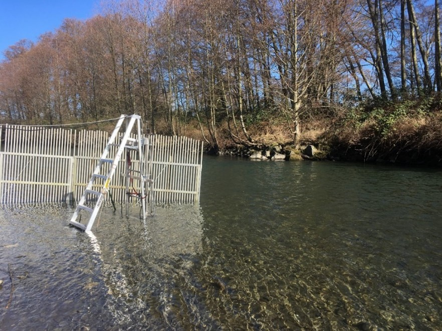

Figure 3.3: SONAR unit deployment via a pole mount and ladder system in the Dungeness River in 2018.

Midway through the 2019 season the SONAR unit was mounted on a semi-permanent platform along the hardened west bank, in a spot that is protected and retains adequate depth so that the SONAR unit did not need to be shifted laterally to accommodate changing water levels (Figure 3.4).

In all years, a picket weir was constructed approximately 1 meter upstream of the SONAR unit from the bank, extending out to approximately 1 meter past the SONAR, to deflect debris (Figure 3.4). A second picket weir was constructed approximately 1 meter downstream of the SONAR unit to direct migrating fish out in front of the unit.

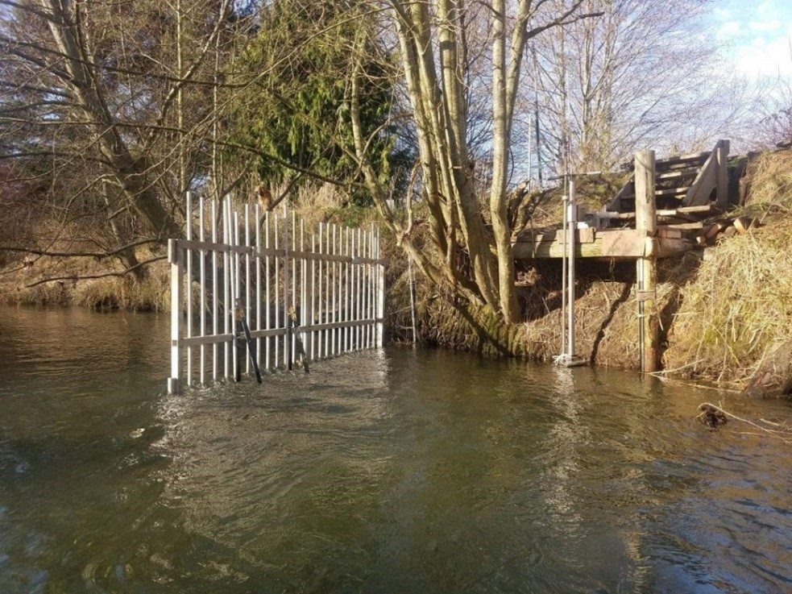

Figure 3.4: SONAR unit deployment via a pole mount and platform in the Dungeness River in 2020. Picket weir is the upstream picket weir.

Table 3.1: Table 3.2: SONAR operational dates on the Dungeness River, 2018 - 2024.

| Year | First Date | Last Date |
| --- | --- | --- |
| 2018 | Feb 28 | Jul 16 |
| 2019 | Mar 05 | Jul 17 |
| 2020 | Feb 13 | Jul 26 |
| 2021 | Feb 01 | Jun 22 |
| 2022 | Feb 09 | Jun 25 |
| 2023 | Feb 07 | Jun 20 |
| 2024 | Jan 01 | Jun 15 |

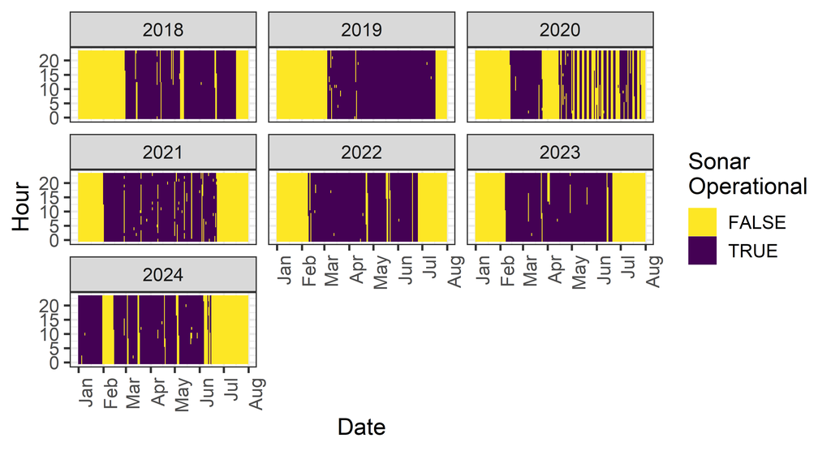

Figure 3.5: Plot of when SONAR was operational (purple) and not (yellow), from January 1 through July 31 each year.

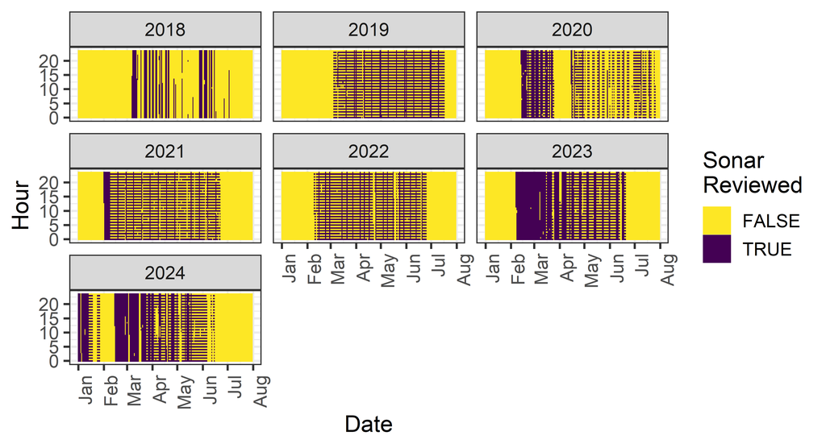

Figure 3.6: Plot of when SONAR was reviewed (purple) and not (yellow), from January 1 through July 31 each year.

## 3.2 Data Processing

Table 3.3: Table 3.4: The percentage of time between January and mid-June that the SONAR was operational, and how much of the total time was reviewed, 2018 - 2024.

| Year | First Day | Last Day | Pct Operational | Pct Reviewed |
| --- | --- | --- | --- | --- |
| 2018 | Jan 01 | Jun 15 | 59.1% | 23.4% |
| 2019 | Jan 01 | Jun 15 | 60.8% | 34.2% |
| 2020 | Jan 01 | Jun 15 | 51.0% | 31.3% |
| 2021 | Jan 01 | Jun 15 | 76.4% | 43.7% |
| 2022 | Jan 01 | Jun 15 | 71.9% | 41.1% |
| 2023 | Jan 01 | Jun 15 | 74.0% | 59.2% |
| 2024 | Jan 01 | Jun 15 | 82.2% | 58.2% |

Each reviewed imagery file was processed using Sound Metric’s proprietary software ARISFish (v2.6.3 – v2.8.0). First, raw image files were background subtracted, which removed static objects from the image so that only objects in motion are shown. Then, an echogram was created, which transformed the image into a graph of distance (y-axis) and time (x-axis), so that objects in motion appeared as white “tracks.” The echogram enabled the data reviewer to quickly navigate to parts of the image file that contained objects that could be migrating fish. These tracks were then manually viewed alongside the raw image file to determine if the object was a fish to be further investigated.

Fish greater or equal to 45 centimeters (cm) were measured, marked, and counted using the ARISFish software. Forty-five cm was determined to be the minimum length of a potential steelhead, based on captures of steelhead during sampling in the Dungeness River 2014, 2015, and 2017 by the Jamestown S’Klallam Tribe (JSK) (unpublished data, C. Burns). Only fish that completely moved through the SONAR beams were counted; fish that nosed in and out or did not completely move from one side of the beams to the other were not counted.

For each fish counted the following data were recorded:

- Date
- Hour of the 30-minute image file (e.g., 14:00, 14:30)
- Time
- Frame
- Direction of travel (upstream or downstream)
- Range (distance from the SONAR)
- Length of the fish in cm
- Data reviewer confidence (1 = extremely confident that the object counted is a fish $\geq$ 45 cm, 2 = somewhat confident that the object is a fish $\geq$ 45 cm, 3 = object of interest)

If no fish were observed in the 30-minute image file, a line of data with “NO FISH” was recorded to indicate that the file was reviewed for fish, but no fish $\geq$ 45 cm were present. Counted fish were automatically saved within the image file for later error checking; data were also recorded within an Excel spreadsheet for data summarization and analysis.

## 3.3 Data Reviewer Comparison

In several years (2019 - 2024), a subset of SONAR footage was reviewed by all (two or three) of that years’ observers (Table 3.5). Within that subset of data, we summed the counts of each observer by date and direction before calculating the correlations between counts of different observers using the Pearson correlation coefficient. One observer (initial AS) was an observer every year, while other observers worked for one or two years only. We combined the daily counts across years when computing the correlation between observers. We also computed separate correlations for upstream and downstream counts.

To compare length measurements, we attempted to group individual observer detections of the same fish. We did this by first grouping fish detected in the same hour period moving in the same direction. If there was more than one fish detected in that group, we assumed that the relative lengths assigned by each observer corresponded to the same fish (i.e. the smallest observed fish by observer A was also the smallest observed fish by observer B). We then calculated the mean, standard deviation and coefficient of variation (CV) of the length measurements for each fish. Because observer AS was the most experienced, and measured nearly every fish, we also compared other observer length measurements against those by AS and treated the measurements by AS as the benchmark for these comparisons. We summarized those differences with statistics such as mean bias, mean absolute error (MAE), root mean squared error (RMSE) and mean absolute percent error (MAPE).

Table 3.5: Table 3.6: Number of distinct days, hours and individual fish that were double or triple reviewed each year.

| Year | n Days | n Hours | n Fish |
| --- | --- | --- | --- |
| 2019 | 5 | 32 | 54 |
| 2020 | 6 | 34 | 51 |
| 2021 | 12 | 65 | 92 |
| 2022 | 14 | 69 | 116 |
| 2023 | 12 | 221 | 773 |
| 2024 | 12 | 113 | 239 |

## 3.4 Species Composition Sampling

Species composition sampling was conducted weekly, as river conditions allowed, during the period of SONAR operations in 2021-2024. A fine monofilament gill net 5.5 meters wide by 2.4 meters deep with a 5-cm mesh (10-cm stretch) was drifted through all sampleable habitat in the lower river from RKM 5.3 to RKM 0.8 (2021) or RKM 1.3 (2022 - 2024). In habitat where it wasn’t possible to use a net (e.g., too much wood), hook and line sampling occurred. Encountered fish were removed immediately from the net, sedated in a solution of tricaine methanesulfonate (MS-222), and sampled for species, mark status, length, sex, scales, and DNA. Hatchery-origin steelhead were identified by adipose fin clip. Captured steelhead were assessed for kelt status.

No regular species composition sampling was conducted in 2018, 2019, or 2020. In 2019, three sampling efforts targeting bull trout (*Salvelinus confluentus*) were conducted once per week in June at sites throughout the Dungeness and Gray Wolf rivers.

## 3.5 Determining Species

Bull trout moved past the SONAR unit as well as steelhead. We needed to parse which fish identified by the SONAR were steelhead, and exclude any bull trout. We modeled the probability of a fish being a steelhead using fork length and the Julian day of capture from the 2021-2024 species composition data, including both natural-origin and hatchery-origin steelhead. Since our primary objective was differentiating steelhead from other fish, we grouped resident rainbow and cutthroat trout (*Oncorhynchus clarkii*) with bull trout, and then fit a binomial generalized additive model (GAM) with a logit link, using splines of fork length and Julian day, to predict the probability of a fish being a steelhead.

After fitting this GAM, we predicted the probability of being a steelhead for all fish observed on the SONAR. Any fish with a probability of 50% or greater we assigned as a steelhead.

## 3.6 Abundance Estimation

For 2019-2024, SONAR fish targets that had a greater than or equal to 50% probability of being a steelhead, moved completely through the SONAR beams (direction of travel was upstream or downstream), and had a data reviewer confidence of 1 were included in the final steelhead counts and abundance estimate. Based in part on the species composition data, we determined that the steelhead run on the Dungeness is over by mid-June, so we restricted the steelhead season to SONAR observations or predictions between January 1 and June 15.

To fill in the missing data from periods when the SONAR was not operating or the data had not been reviewed, this dataset was fit with a negative binomial generalized additive model (GAM) with a log link function using hour of day, discharge (from USGS gage 12048000 on the Dungeness River, summarized at the hour timescale) and Julian day-of-year as covariates. The GAM include a cubic spline for the hour of day, a thin-plate spline for discharge, and a factor spline for day of year, including an interaction between year and day of year. This GAM was then used to predict the upstream and downstream numbers of steelhead during all missing data periods, from January 1 through June 15 each year. This included all half hours when the SONAR was not operational for the entire 30 min, as well as all half hours that were not reviewed.

To combine the upstream and downstream estimates, we made one simplifying assumption related to kelting behavior similar to the process outlined in Metheny (2012) and Metheny and Duffy (2014). Prior to May 15, we subtracted the total estimate of downstream moving fish from the total estimate of upstream moving fish. This is to prevent fish that are milling (moving upstream, then downstream, then upstream again) from being double counted. After May 15, we ignored downstream moving fish and only estimated upstream moving fish, under the assumption that downstream moving fish were steelhead kelts that had spawned and therefore should not be subtracted from our escapement estimates. Obviously, there may be kelts moving downstream prior to May 15, and there may be milling fish after that date, but our assumption was that the number of downstream moving kelts prior to that date equals the number of downstream milling fish after that date.

### 3.6.1 Comparison with Redd-Based Estimates

The Jamestown S’Klallam Tribe has conducted redd surveys for steelhead on the Dungeness for many years. In most years, rising flows and increased turbidity close the river to surveyors before the end of steelhead spawning season. However, in 2015, conditions allowed for surveys to be completed through the end of the spawning season. For other years, the number of redds surveyed is expanded by the proportion of total redds observed in 2015 up to the date of the last survey in that year. These estimates of total redds are then expanded to spawners by multiplying by a fish / redd constant of 1.62. We compared the SONAR-based estimates of steelhead escapement to the redd-based estimates of steelhead spawners for 2019, 2021, 2022, 2023 and 2024. Due to COVID, no redd surveys were conducted in 2020, so no redd-based estimate was available for that year.

# 4 Results

## 4.1 Data Reviewer Comparison

After summing the counts across days when each pair of observers reviewed the same footage, Table 4.1 shows the total counts by year and direction (upstream vs. downstream) for each observer. Generally, the upstream counts are very well aligned, and the downstream counts are close, although they show more observer-to-observer variability than upstream counts.

Table 4.1: Table 4.2: Total counts of steelhead by direction and year for each observer pair during days when both observers were counting.

Year

Direction

AB

AS

BC

BP

BT

CS

GB

JE

JG

SM

2019

Upstream

38

38

38

37

38

37

2020

31

32

2021

14

13

26

26

3

3

2022

47

48

54

40

46

32

2023

269

350

348

358

266

358

2024

57

79

57

43

53

100

1

2

8

7

2019

Downstream

6

7

7

5

9

7

2020

15

12

2021

19

19

24

20

6

1

2022

20

12

24

13

9

6

2023

205

211

211

179

206

180

2024

32

39

35

16

27

63

3

2

5

8

Table 4.3: Table 4.4: Correlation (r) between daily counts of upstream and downstream moving fish for periods that were reviewed by pairs of observers. The total number of days when each pair reviewed SONAR data is shown, as well as the total number of fish observed by each observer.

Direction

Obs 1

Obs 2

N Days

Obs 1 Fish

Obs 2 Fish

r

Upstream

AS

JG

5

38

37

0.998

BC

JG

5

38

37

0.995

AS

BC

5

38

38

0.991

AS

JE

15

405

459

0.988

AS

BT

11

45

45

0.976

BP

SM

3

0.971

AS

AB

10

350

269

0.968

AB

JE

9

266

459

0.956

JE

BP

7

0.953

AS

CS

15

73

74

0.951

AS

BP

6

57

61

0.767

CS

GB

8

46

42

0.495

AS

GB

10

54

42

0.404

Downstream

JE

BP

5

0.996

AS

BP

5

35

33

0.983

AS

AB

10

211

208

0.963

AS

JE

15

243

249

0.890

AB

JE

11

206

249

0.874

AS

BC

3

6

7

0.866

AS

BT

10

34

31

0.863

AS

CS

14

44

33

0.654

AS

GB

7

24

13

0.541

BC

JG

3

7

7

0.500

AS

JG

4

9

7

0.174

BP

SM

3

-0.189

CS

GB

5

9

13

-0.250

For fish observed by multiple observers, the CVs of those multiple length measurements are displayed in Figure 4.1. The mean CV of length measurements for upstream moving fish was 0.09, while it was 0.10 for downstream moving fish. 86% of the upstream CVs were smaller than 0.15 (considered a reference point for precise measurements), while 78% of the downstream CVs met this criterion.

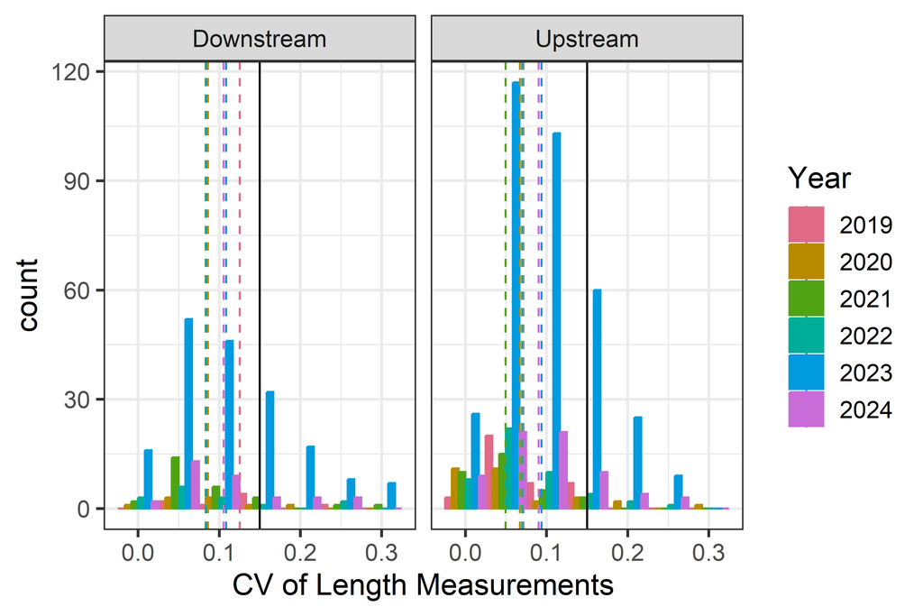

Figure 4.1: Coefficient of variation (CV) of length measurements for individual fish across multiple observers, colored by year and faceted by direction of movement. Dashed lines indicate the mean CV for that group, while the solid black line is a reference of 0.15.

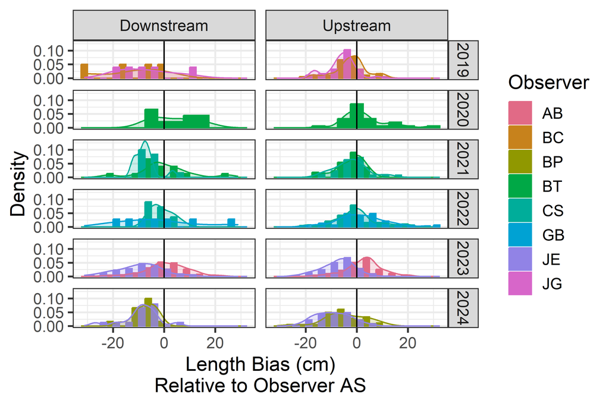

Figure 4.2: Histograms and density plots showing the bias of length measurements, relative to observer AS, colored by observer and faceted by direction and year.

Table 4.5: Table 4.6: Summary statistics comparing length measurements of different observers with those made by observer AS.

| Direction | Observer | N Fish | Mean Bias | RMSE | MAE | MAPE |
| --- | --- | --- | --- | --- | --- | --- |
| Upstream | JE | 344 | -7.7 | 10.2 | 8.4 | 11.6 |
| Upstream | AB | 224 | 2.9 | 7.7 | 6.1 | 9.1 |
| Upstream | CS | 63 | -1.1 | 7.8 | 5.7 | 8.9 |
| Upstream | BT | 41 | 1.5 | 8.3 | 5.7 | 9.1 |
| Upstream | JG | 37 | -6.3 | 8.3 | 6.8 | 9.3 |
| Upstream | BC | 36 | -2.3 | 6.7 | 4.9 | 6.7 |
| Upstream | BP | 36 | -4.2 | 9.2 | 7.5 | 10.4 |
| Upstream | GB | 29 | 1.9 | 9.6 | 7.4 | 12.3 |
| Downstream | JE | 143 | -9.7 | 13.0 | 10.8 | 14.5 |
| Downstream | AB | 122 | 1.2 | 8.7 | 6.6 | 9.5 |
| Downstream | BT | 24 | 1.5 | 9.7 | 7.4 | 12.6 |
| Downstream | CS | 23 | -4.4 | 6.8 | 6.0 | 8.9 |
| Downstream | BP | 12 | -7.5 | 8.7 | 7.5 | 9.9 |
| Downstream | GB | 7 | -2.0 | 15.1 | 12.4 | 18.2 |
| Downstream | JG | 5 | -7.4 | 12.1 | 10.7 | 13.0 |
| Downstream | BC | 4 | -12.4 | 17.0 | 13.0 | 14.5 |

## 4.2 Species Composition

Table 4.7: Table 4.8: Counts of species encountered during species composition sampling in the lower Dungeness River in 2021 - 2024, with steelhead differentiated by mark status (marked (AD) or unmarked (UM)) and kelt status.

| Year | Date | Bull Trout | Cutthroat | Rainbow (UM) | Steelhead (UM) | Steelhead (AD) | Steelhead Kelt (UM) | Steelhead Kelt (AD) |
| --- | --- | --- | --- | --- | --- | --- | --- | --- |
| 2021 | Feb 03 | 3 | 0 | 0 | 0 | 0 | 0 | 0 |
|  | Feb 17 | 1 | 0 | 0 | 3 | 0 | 0 | 0 |
|  | Feb 25 | 0 | 0 | 0 | 2 | 0 | 0 | 0 |
|  | Mar 01 | 0 | 0 | 0 | 0 | 0 | 0 | 0 |
|  | Mar 17 | 0 | 0 | 0 | 1 | 0 | 0 | 0 |
|  | Mar 25 | 0 | 0 | 0 | 2 | 0 | 0 | 0 |
|  | Apr 01 | 0 | 0 | 0 | 1 | 1 | 0 | 0 |
|  | Apr 08 | 0 | 0 | 0 | 5 | 1 | 0 | 0 |
|  | Apr 14 | 0 | 0 | 0 | 4 | 0 | 0 | 0 |
|  | Apr 28 | 2 | 0 | 0 | 1 | 0 | 0 | 0 |
|  | May 06 | 0 | 0 | 0 | 0 | 0 | 0 | 0 |
|  | May 12 | 0 | 0 | 0 | 0 | 0 | 0 | 0 |
|  | Jun 08 | 3 | 0 | 0 | 0 | 0 | 0 | 0 |
|  | Jun 09 | 0 | 0 | 0 | 0 | 0 | 1 | 0 |
|  | Jun 17 | 2 | 0 | 0 | 0 | 0 | 0 | 0 |
|  | Total | 11 | 0 | 0 | 19 | 2 | 1 | 0 |
| 2022 | Feb 02 | 3 | 1 | 0 | 0 | 0 | 0 | 0 |
|  | Feb 09 | 0 | 1 | 0 | 0 | 0 | 0 | 0 |
|  | Feb 15 | 1 | 0 | 0 | 0 | 0 | 0 | 0 |
|  | Feb 22 | 0 | 0 | 0 | 2 | 0 | 0 | 0 |
|  | Mar 09 | 1 | 0 | 0 | 1 | 1 | 0 | 0 |
|  | Mar 16 | 1 | 0 | 0 | 2 | 2 | 0 | 0 |
|  | Mar 23 | 1 | 0 | 0 | 2 | 0 | 0 | 0 |
|  | Mar 30 | 0 | 0 | 0 | 2 | 0 | 0 | 0 |
|  | Apr 07 | 1 | 0 | 0 | 3 | 0 | 0 | 0 |
|  | Apr 19 | 3 | 0 | 0 | 7 | 0 | 0 | 0 |
|  | May 04 | 2 | 0 | 0 | 2 | 0 | 4 | 0 |
|  | May 20 | 2 | 0 | 0 | 1 | 0 | 1 | 1 |
|  | Jun 01 | 2 | 0 | 0 | 0 | 0 | 1 | 0 |
|  | Jun 22 | 1 | 0 | 0 | 0 | 0 | 0 | 0 |
|  | Total | 18 | 2 | 0 | 22 | 3 | 6 | 1 |
| 2023 | Feb 01 | 4 | 0 | 0 | 0 | 0 | 0 | 0 |
|  | Feb 08 | 6 | 0 | 0 | 2 | 1 | 0 | 0 |
|  | Feb 16 | 1 | 0 | 0 | 1 | 0 | 0 | 0 |
|  | Mar 02 | 4 | 0 | 0 | 0 | 1 | 0 | 0 |
|  | Mar 09 | 1 | 0 | 0 | 1 | 0 | 0 | 0 |
|  | Mar 16 | 0 | 0 | 0 | 0 | 0 | 0 | 0 |
|  | Mar 23 | 4 | 0 | 0 | 0 | 0 | 0 | 0 |
|  | Mar 30 | 2 | 0 | 0 | 6 | 0 | 0 | 0 |
|  | Apr 06 | 3 | 0 | 0 | 11 | 0 | 0 | 0 |
|  | Apr 13 | 5 | 0 | 0 | 5 | 0 | 1 | 0 |
|  | Apr 20 | 2 | 0 | 0 | 8 | 2 | 3 | 0 |
|  | Apr 27 | 2 | 0 | 0 | 3 | 0 | 1 | 0 |
|  | May 11 | 0 | 0 | 0 | 0 | 0 | 0 | 0 |
|  | May 25 | 0 | 2 | 0 | 0 | 0 | 0 | 0 |
|  | Total | 34 | 2 | 0 | 37 | 4 | 5 | 0 |
| 2024 | Jan 18 | 1 | 0 | 0 | 5 | 0 | 0 | 0 |
|  | Jan 25 | 4 | 0 | 0 | 1 | 0 | 0 | 0 |
|  | Feb 15 | 4 | 0 | 0 | 1 | 0 | 0 | 0 |
|  | Feb 22 | 4 | 0 | 1 | 4 | 0 | 0 | 0 |
|  | Mar 07 | 1 | 0 | 0 | 3 | 0 | 0 | 0 |
|  | Mar 14 | 1 | 0 | 0 | 4 | 0 | 0 | 0 |
|  | Mar 21 | 2 | 0 | 0 | 4 | 0 | 1 | 0 |
|  | Mar 28 | 4 | 0 | 0 | 6 | 0 | 0 | 0 |
|  | Apr 04 | 4 | 0 | 0 | 6 | 0 | 0 | 0 |
|  | Apr 11 | 3 | 1 | 0 | 7 | 1 | 1 | 0 |
|  | Apr 18 | 2 | 0 | 0 | 9 | 0 | 2 | 0 |
|  | Apr 25 | 3 | 0 | 0 | 13 | 0 | 4 | 0 |
|  | May 02 | 2 | 0 | 0 | 5 | 0 | 0 | 0 |
|  | May 10 | 1 | 0 | 0 | 0 | 0 | 1 | 0 |
|  | May 23 | 3 | 0 | 0 | 0 | 0 | 1 | 0 |
|  | May 31 | 1 | 0 | 0 | 0 | 0 | 4 | 0 |
|  | Total | 40 | 1 | 1 | 68 | 1 | 14 | 0 |

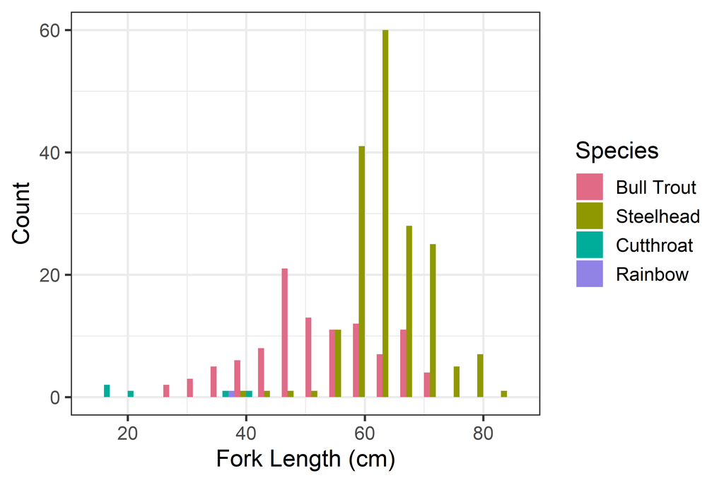

Figure 4.3: Fork length distributions of fish encountered during species composition sampling in the lower Dungeness River in 2021 - 2024, colored by species.

## 4.3 Determining Species

The impacts of Julian day and fork length on the probability of a fish being a steelhead are displayed in Figure 4.4. Generally, larger fish have a greater chance of being a steelhead, but the exact break point of length (i.e. 50% probability of being a steelhead) shifts over the course of the season. The number of estimated steelhead is shown in Table 4.9.

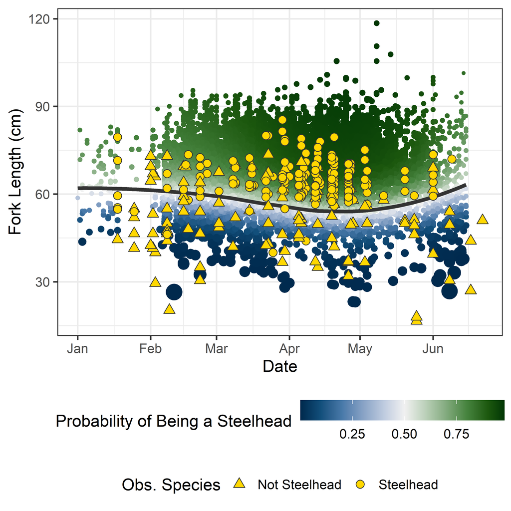

Figure 4.4: Julian day and fork length of each fish detected on SONAR, 2019-2024, colored by the predicted probability of being a steelhead from the GAM. Size of the point corresponds to the precision of the predicted probability (larger points indicate greater precision). Dark line indicates the 50% probability of being a steelhead. Yellow points indicate observed fish from the species composition sampling that were used in the GAM.

Table 4.9: Table 4.10: Number of fish observed moving upstream or downstream from SONAR (n Fish), and how many were estimated (> 50% probability) to be a steelhead according to the species composition GAM (Est. Steelhead).

| Direction | Year | n Fish | Est. Steelhead |
| --- | --- | --- | --- |
| Upstream | 2019 | 776 | 661 |
|  | 2020 | 831 | 692 |
|  | 2021 | 762 | 653 |
|  | 2022 | 734 | 584 |
|  | 2023 | 2,324 | 2,123 |
|  | 2024 | 1,583 | 1,359 |
| Downstream | 2019 | 305 | 267 |
|  | 2020 | 355 | 258 |
|  | 2021 | 419 | 339 |
|  | 2022 | 307 | 235 |
|  | 2023 | 1,596 | 1,438 |
|  | 2024 | 1,096 | 1,005 |

## 4.4 Abundance Estimation

Estimates of early (January 1 - May 15, upstream - downstream), late (May 16 - June 15, upstream only), and total annual escapement of winter steelhead are shown in Table 4.11. The proportions of kelts, measured as the number of downstream moving steelhead counted after May 15 divided by the total annual escapement, are shown in Table 4.13.

Table 4.11: Table 4.12: Annual estimates of winter steelhead escapement to the Dungeness River between January 1 and June 15. Early (January 1- May 15), late (May 16 – June 15), total escapement estimate, standard error and range of the 95% confidence interval (CI).

[output not shown]

Table 4.13: Table 4.14: Proportion of kelts estimated each year, with standard error.

[output not shown]

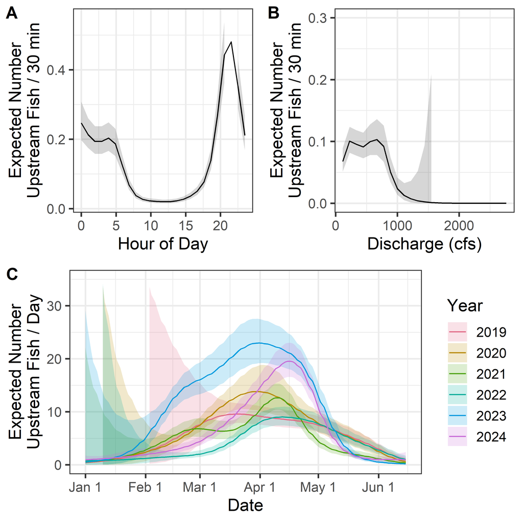

Figure 4.5: Marginal effects for upstream-moving fish as estimated by the GAM for hour of day (A), discharge (B), and Julian day of year (C). Shaded areas indicated 95% confidence intervals.

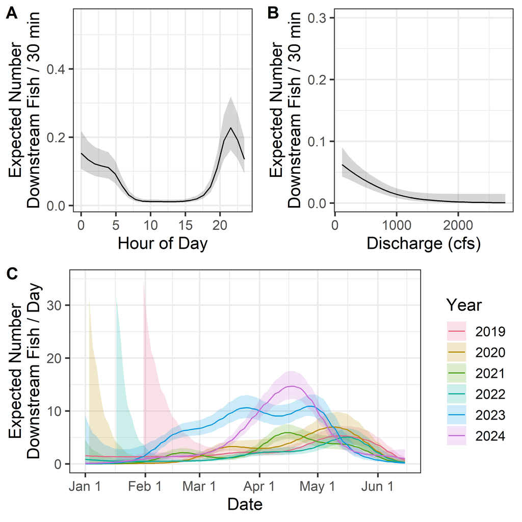

Figure 4.6: Marginal effects for downstream-moving fish as estimated by the GAM for hour of day (A), discharge (B), and Julian day of year (C). Shaded areas indicated 95% confidence intervals.

### 4.4.1 Comparison with Redd-Based Estimates

Table 4.15: Table 4.16: Annual estimates of winter steelhead escapement to the Dungeness River based on redd counts and SONAR (with 95% confidence intervals and standard error (SE))

Year

Redd Est.

SONAR Est.

SE

Low CI

Upp CI

2019

467

980

479.7

-579

1,443

2020

1,195

262.1

1,065

2,047

2021

329

715

81.1

661

937

2022

386

780

272.9

-170

840

2023

309

995

111.7

927

1,313

2024

402

554

26.3

534

609

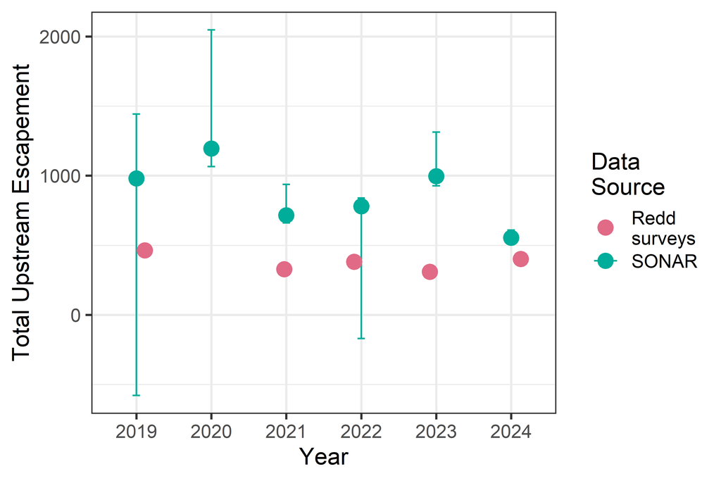

Figure 4.7: Annual estimates of winter steelhead escapement to the Dungeness River, based on SONAR (with 95% confidence intervals) and redd counts.

# 5 Discussion

We used SONAR to make annual estimates of winter steelhead escapement on the Dungeness River for spawn years 2019-2024. To do so, we needed to collect and utilize independent species composition data, and develop an analysis technique that allowed us to estimate passage during periods when the SONAR was not operable or the video had not been reviewed. Analyzing these initial years of data has prompted several observations worth mentioning.

In addition to fish behavior at the site, access and security are important considerations. After we moved the SONAR site slightly upstream in 2019 and deployed the unit from a fixed platform on the bank, it was much easier for the team to check on and make adjustments to the unit. The 2019-2024 site is also located on WDFW property, enabling a direct power source, and an on-site staff trailer for security and comfort in bad weather.

Second, the variability between observers was relatively small. The total counts between pairs of observers each year were very similar, especially for upstream moving fish (Table 4.1). The coefficient of variation among different observers’ length measurements was quite small, suggesting good consistency across observers. It should be noted that we matched up which fish each observer measured in such a way as to minimize observer-to-observer differences for multiple fish observed in the same half-hour period. The overall bias in measurements, compared to observer AS, was quite low, but not zero. This could have an impact on whether a fish is predicted to be a steelhead or not, since length is a determining covariate in the species prediction model. However, Figure 4.2 suggests that there are differences in length measurements in both the positive and negative direction, so the impact on steelhead counts should be minimal.

Third, how to best deal with steelhead kelts is an open question. For fish that move upstream, downstream, and upstream again before spawning, we would like to subtract the downstream counts from the upstream counts, to avoid double-counting the same fish. However, steelhead that kelt may be observed moving upstream and again moving downstream, and we do not want those counts to cancel each other out. Currently, we are sidestepping this issue by assuming that the number of kelts detected prior to May 15 is equal to the number of downstream milling detections after that date. However, that date is at best an educated guess which could lead to bias in our estimates in one direction or the other. Continued investigation of this issue is warranted, perhaps by more closely examining the species composition data for kelting behavior (or changing the species composition sampling to better target kelts) or by analyzing metrics such as the upstream:downstream count ratios through the season, to determine if there is a pattern that could guide what that equilibrium date should be.

In an effort to better understand the timing of kelt movement, in 2024 we started a project to acoustically tag a sample of upstream moving steelhead. Using existing acoustic receivers positioned throughout the Dungeness watershed, we hope to learn when kelts are likely to be passing the SONAR moving downstream, and whether the timing of when kelts are detected is related to the timing of when they initially pass the SONAR while migrating upstream. This information should help better inform the choice of a date to separate downstream milling versus kelting behavior, or provide data to improve the approach to analyzing kelts.

Finally, the species composition data raised a few issues for future consideration. A few bull trout were captured multiple times in the same pool during species composition netting, suggesting that the species composition sampling may be sampling not just fish that are moving, but also fish that may be holding (i.e. not moving past the SONAR). Whether this actually impacts the predictions of species based on size and Julian day is unclear. To better identify holding fish, in 2024 we are tagging all bull trout and steelhead (that aren’t acoustic tagged) with individually numbered FLOY tags. In addition, the current species composition methods cannot account for potential differences in what hour of the day certain species are more or less likely to move. If steelhead are more likely to move at night, as suggested by the hour of day co-variate in our model, compared to other species, we would want to incorporate hour of day into our species prediction. Without a different study design for species composition, we are unable to address this question. However, it seems reasonable to assume that steelhead and bull trout have similar behavior with regards to movement and time of day. With regard to steelhead origin, 1.4 - 12% of the steelhead caught each year during species composition sampling were hatchery-origin. We did not distinguish between natural-origin and hatchery-origin steelhead in our abundance estimates, but in future years we could consider estimating pHOS.

## 5.1 Recommendations

In the future, we recommend setting the SONAR unit up earlier in the year, before the steelhead start moving upstream into the Dungeness River. Even in 2021, when the SONAR was deployed starting February 1, there was still one steelhead detected on that date, suggesting the run may begin sooner than that. If the SONAR is deployed earlier, then we would also recommend that the species composition sampling begin at the same point in the year that the SONAR is deployed, to ensure that we can identify when steelhead (as opposed to other species) are moving in the Dungeness. In 2024 we deployed the SONAR in late December, and we began the species composition sampling in January. After a few years of deploying earlier, we may be able to move the deployment date later based on our better understanding of when the run starts.

We also recommend investigating the use of image recognition software and machine learning processing to help automate the review of SONAR images. Technicians are required to spend a substantial amount of time reviewing SONAR video, and if that could be reduced it would have multiple benefits. First, cutting hours of tedious review time could potentially be cost-effective, and make the data available for analysis sooner. Second, it would make the counts more reproducible and less subject to an individual observer’s skill and experience. Finally, by automating the review process there would no longer be a need to selectively choose which periods to review (e.g., first 30 minutes of every hour). Instead, counts could be obtained for the entire period the SONAR is deployed, reducing the reliance on estimates for periods with missing data.

Additionally, we recommend considering study design changes to the species composition sampling to answer the questions we have with these data. We could consider constraining the species composition sampling closer to the SONAR site to attempt to capture only fish actively migrating, and not fish that are holding. We could also consider modifying the species composition sampling to attempt to estimate pHOS in different parts of the river. We also recommend testing whether time of day affects the species composition by doing some sampling sets in the late afternoon and evening, or possibly some snorkel counts during the day and night.

# 6 Acknowledgements

Andrew Simmons, Dan Gorze, Jayson Gallatin, Brent Trim, Greg Boecker, and Jake Eastby of WDFW operated, maintained, and reviewed SONAR imagery data. Calvin Stokes, Alec Bauer, and Bethany Craig also reviewed SONAR imagery. Keith Denton provided guidance and consultation on SONAR deployment and operation. Peter Topping provided project support and advice. Kathryn Sutton led weekly species composition sampling with the help of many staff including Calvin Stokes, Trevor Allen, Jenni Whitney, Scott Williams, Jeff Gufler, David Thomas, Jacob Portney, Caleb Owen, and Kayla Own of WDFW, Chris Burns, Jarrett Burns, Casey Allen, and Aaron Brooks of the Jamestown S’Klallam Tribe, Dave Shreffler of Shreffler and Associates, Keith Denton of Keith Denton and Associates, and Roger Peters, Roger Tabor, Greg Byford, Evan Lewis, Jakob Bengelink, and Jack Brill of the U.S. Fish and Wildlife Service.

# 7 Literature Cited

Ford, M. J., A. Albaugh, K. Barnas, T. D. Cooney, J. Cowen, J. J. Hard, R. G. Kope, M. M. McClure, P. McElhany, J. M. Myers, and others. 2011. Status review update for Pacific salmon and steelhead listed under the Endangered Species Act: Pacific Northwest. NOAA Fisheries, NMFS-NWFSC-113, Northwest Fisheries Science Center Seattle.

Metheny, M. 2012. Use of Dual Frequency Identification SONAR to Estimate Salmonid Escapement to Redwood Creek, Humboldt County California. Master’s thesis, Humboldt State University.

Metheny, M., and W. Duffy. 2014. Sonar estimation of adult salmonid abundance in Redwood Creek, Humboldt County 2012-2013. California Department of Fish and Wildlife.

Murdoch, A. R., C. J. Herring, C. H. Frady, K. See, and C. E. Jordan. 2018. [Estimating observer error and steelhead redd abundance using a modified Gaussian area-under-the-curve framework](https://doi.org/10.1139/cjfas-2017-0335). Canadian Journal of Fisheries and Aquatic Sciences 75(12):2149–2158.

Myers, J. M., J. J. Hard, E. J. Connor, R. A. Hayman, R. G. Kope, G. Lucchetti, A. R. Marshall, G. R. Pess, and B. E. Thomson. 2015. Identifying historical populations of steelhead within the Puget Sound distinct population segment. U.S. Department of Commerce, NMFS- NWFSC-128.

Northwest Fisheries Science Center. 2015. Status review update for Pacific salmon and steelhead listed under the Endangered Species Act: Pacific Northwest. NOAA Fisheries, Northwest Fisheries Science Center Seattle.

WDFW. 2024. 2023 early winter steelhead annual report: Dungeness, Nooksack, Stillaguamish, and Snohomish hatchery programs. Washington Department of Fish and Wildlife, Olympia, WA.